# White Wines Quality Analysis by Andre Kenji Yai

# Description

P. Cortez, A. Cerdeira, F. Almeida, T. Matos and J. Reis. Modeling wine preferences by data mining from physicochemical properties. In Decision Support Systems, Elsevier, 47(4):547-553. ISSN: 0167-9236.

In the above reference, two datasets were created, using red and white wine samples. The inputs include objective tests (e.g. PH values) and the output is based on sensory data (median of at least 3 evaluations made by wine experts). Each expert graded the wine quality between 0 (very bad) and 10 (very excellent). Several data mining methods were applied to model these datasets under a regression approach. The support vector machine model achieved the best results. Several metrics were computed: MAD, confusion matrix for a fixed error tolerance (T), etc. Also, we plot the relative importances of the input variables (as measured by a sensitivity analysis procedure).

Number of Attributes: 11 + output attribute

Note: several of the attributes may be correlated, thus it makes sense to apply some sort of feature selection.

Attribute information:

For more information, read [Cortez et al., 2009].

Input variables (based on physicochemical tests): - 1. fixed acidity (tartaric acid - g / dm^3) - 2. volatile acidity (acetic acid - g / dm^3) - 3. citric acid (g / dm^3) - 4. residual sugar (g / dm^3) - 5. chlorides (sodium chloride - g / dm^3 - 6. free sulfur dioxide (mg / dm^3) - 7. total sulfur dioxide (mg / dm^3) - 8. density (g / cm^3) - 9. pH - 10. sulphates (potassium sulphate - g / dm3) - 11. alcohol (% by volume) Output variable (based on sensory data): - 12. quality (score between 0 and 10)

# The Problem

We will analiyze the dataset to investigate the features that makes a good wine. In this problem we will use the White Wine dataset.

# Univariate Plots Section

In this section, I will perform some preliminary exploration of your dataset.

Let’s start our analysis by summarizing the data and getting to know more about the dataset.

```
## [1] 4898   13
```

In our dataset there are 4898 rows and 13 features and the features are:

```r
names(WhiteWines)
```

```
##  [1] "X"                    "fixed.acidity"        "volatile.acidity"
##  [4] "citric.acid"          "residual.sugar"       "chlorides"
##  [7] "free.sulfur.dioxide"  "total.sulfur.dioxide" "density"
## [10] "pH"                   "sulphates"            "alcohol"
## [13] "quality"
```

Let’s see the first rows of the dataset

```r
head(WhiteWines,n=10)
```

```
##     X fixed.acidity volatile.acidity citric.acid residual.sugar chlorides
## 1   1           7.0             0.27        0.36           20.7     0.045
## 2   2           6.3             0.30        0.34            1.6     0.049
## 3   3           8.1             0.28        0.40            6.9     0.050
## 4   4           7.2             0.23        0.32            8.5     0.058
## 5   5           7.2             0.23        0.32            8.5     0.058
## 6   6           8.1             0.28        0.40            6.9     0.050
## 7   7           6.2             0.32        0.16            7.0     0.045
## 8   8           7.0             0.27        0.36           20.7     0.045
## 9   9           6.3             0.30        0.34            1.6     0.049
## 10 10           8.1             0.22        0.43            1.5     0.044
##    free.sulfur.dioxide total.sulfur.dioxide density   pH sulphates alcohol
## 1                   45                  170  1.0010 3.00      0.45     8.8
## 2                   14                  132  0.9940 3.30      0.49     9.5
## 3                   30                   97  0.9951 3.26      0.44    10.1
```

[output cut: 18 more lines]

We got that our features are numerical and most are double and it seems X the id of the row.

Lets summarize the data to know more about the mean and perticiles of each feature.

```r
summary(WhiteWines)
```

```
##        X        fixed.acidity    volatile.acidity  citric.acid
##  Min.   :   1   Min.   : 3.800   Min.   :0.0800   Min.   :0.0000
##  1st Qu.:1225   1st Qu.: 6.300   1st Qu.:0.2100   1st Qu.:0.2700
##  Median :2450   Median : 6.800   Median :0.2600   Median :0.3200
##  Mean   :2450   Mean   : 6.855   Mean   :0.2782   Mean   :0.3342
##  3rd Qu.:3674   3rd Qu.: 7.300   3rd Qu.:0.3200   3rd Qu.:0.3900
##  Max.   :4898   Max.   :14.200   Max.   :1.1000   Max.   :1.6600
##  residual.sugar     chlorides       free.sulfur.dioxide
##  Min.   : 0.600   Min.   :0.00900   Min.   :  2.00
##  1st Qu.: 1.700   1st Qu.:0.03600   1st Qu.: 23.00
##  Median : 5.200   Median :0.04300   Median : 34.00
##  Mean   : 6.391   Mean   :0.04577   Mean   : 35.31
##  3rd Qu.: 9.900   3rd Qu.:0.05000   3rd Qu.: 46.00
##  Max.   :65.800   Max.   :0.34600   Max.   :289.00
##  total.sulfur.dioxide    density             pH          sulphates
##  Min.   :  9.0        Min.   :0.9871   Min.   :2.720   Min.   :0.2200
##  1st Qu.:108.0        1st Qu.:0.9917   1st Qu.:3.090   1st Qu.:0.4100
##  Median :134.0        Median :0.9937   Median :3.180   Median :0.4700
##  Mean   :138.4        Mean   :0.9940   Mean   :3.188   Mean   :0.4898
##  3rd Qu.:167.0        3rd Qu.:0.9961   3rd Qu.:3.280   3rd Qu.:0.5500
##  Max.   :440.0        Max.   :1.0390   Max.   :3.820   Max.   :1.0800
##     alcohol         quality
##  Min.   : 8.00   Min.   :3.000
##  1st Qu.: 9.50   1st Qu.:5.000
##  Median :10.40   Median :6.000
##  Mean   :10.51   Mean   :5.878
##  3rd Qu.:11.40   3rd Qu.:6.000
##  Max.   :14.20   Max.   :9.000
```

There are two categories of variables in this database:

- continuous: ph, alcohol, sulphates, clorides, free sulfur dioxide, total sulfur dioxide, density, residual sugar and acids,
- descrite: X, quality.

We also noticed that those with higher variance are alcohol, free sulfur dioxide, total sulfur dioxide, residual sugar.

We will start analysing the quality that and those variables with high variance

### Quality

Lets see how the wines were ranked.

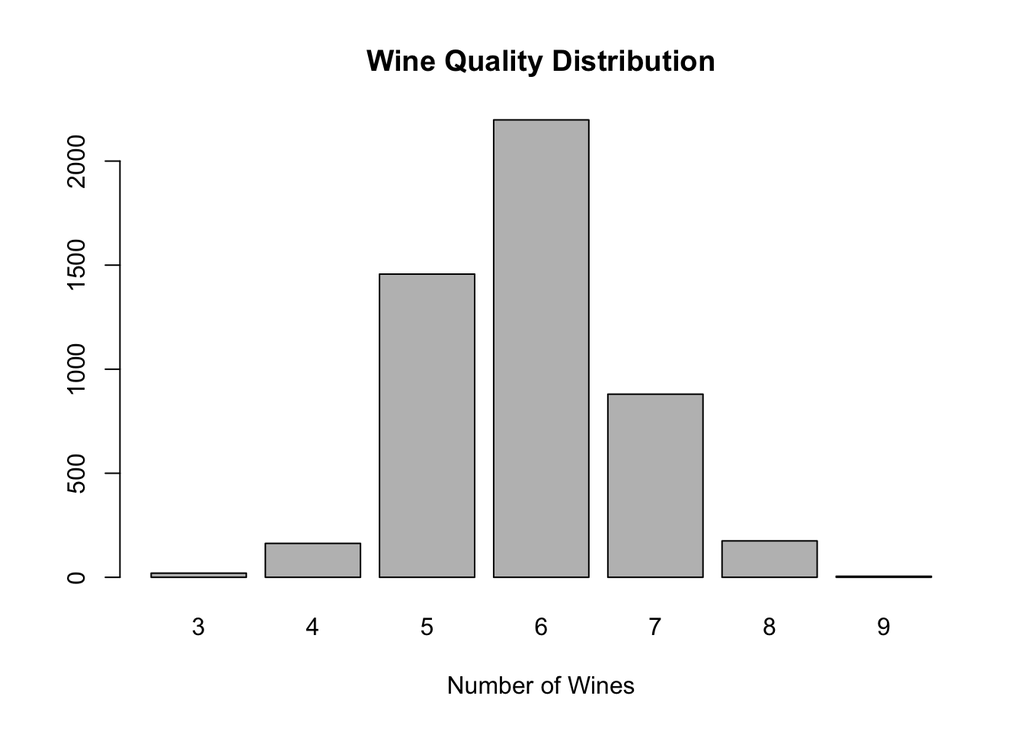

```r
WineQuality <- table(WhiteWines$quality)
barplot(WineQuality, main="Wine Quality Distribution", xlab="Number of Wines")
```

We got that Wine Quality distribution look like a Normal Distribution with the most wines was ranked with a 6 followed by 5 and the lowest received a 3 and the highest a 9.

I wonder what can contribute to that grades? So lets look now at those with higher variance and how they are distributed.

As we have a descrite and specific set of values assigned to quality, I will factorize this feature. Doing so it will help us in the visualization by allowing us to perform better boxplots and investigate relationship of features.

```r
WhiteWines$QualityCategory <-as.factor(WhiteWines$quality)
```

### Alcohol

The porcentage of alcohol content of the wine.

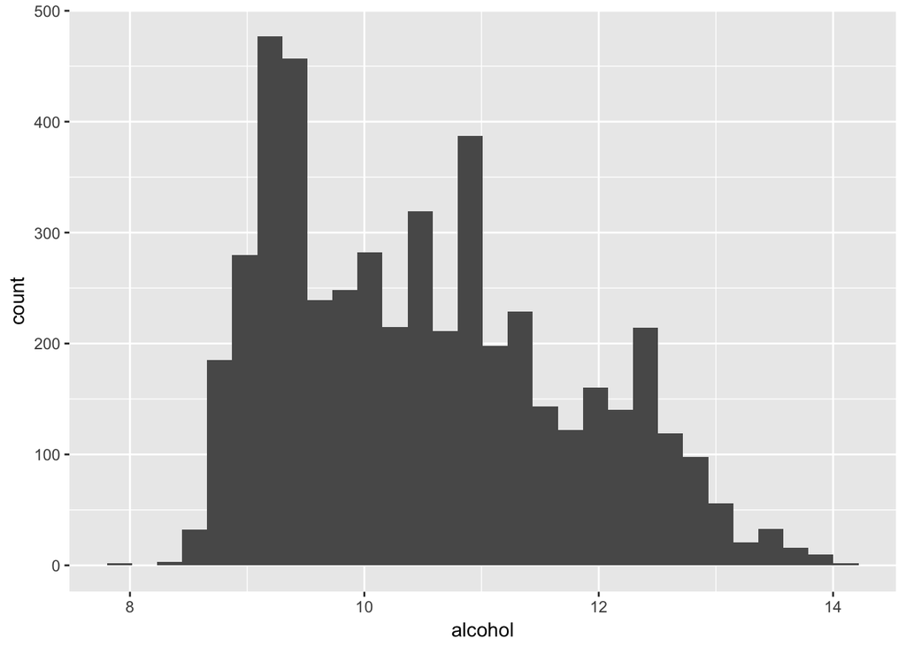

```r
qplot(x = alcohol, data = WhiteWines)
```

```r
summary(WhiteWines$alcohol)
```

```
##    Min. 1st Qu.  Median    Mean 3rd Qu.    Max.
##    8.00    9.50   10.40   10.51   11.40   14.20
```

### Residual Sugar

The amount of sugar remaining after fermentation stops, it’s rare to find wines with less than 1 gram/liter and wines with greater than 45 grams/liter are considered sweet

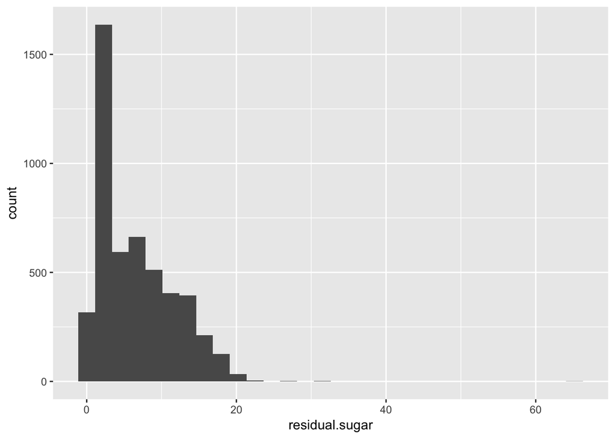

```r
qplot(x = residual.sugar, data = WhiteWines)
```

```r
summary(WhiteWines$residual.sugar)
```

```
##    Min. 1st Qu.  Median    Mean 3rd Qu.    Max.
##   0.600   1.700   5.200   6.391   9.900  65.800
```

```r
length(WhiteWines[(WhiteWines$residual.sugar < 1),]$residual.sugar)
```

```
## [1] 77
```

```r
length(WhiteWines[(WhiteWines$residual.sugar > 45),]$residual.sugar)
```

```
## [1] 1
```

That been investigated we got that we have 77 less than 1 and 1 wine with residual sugar more than 45 g/L.

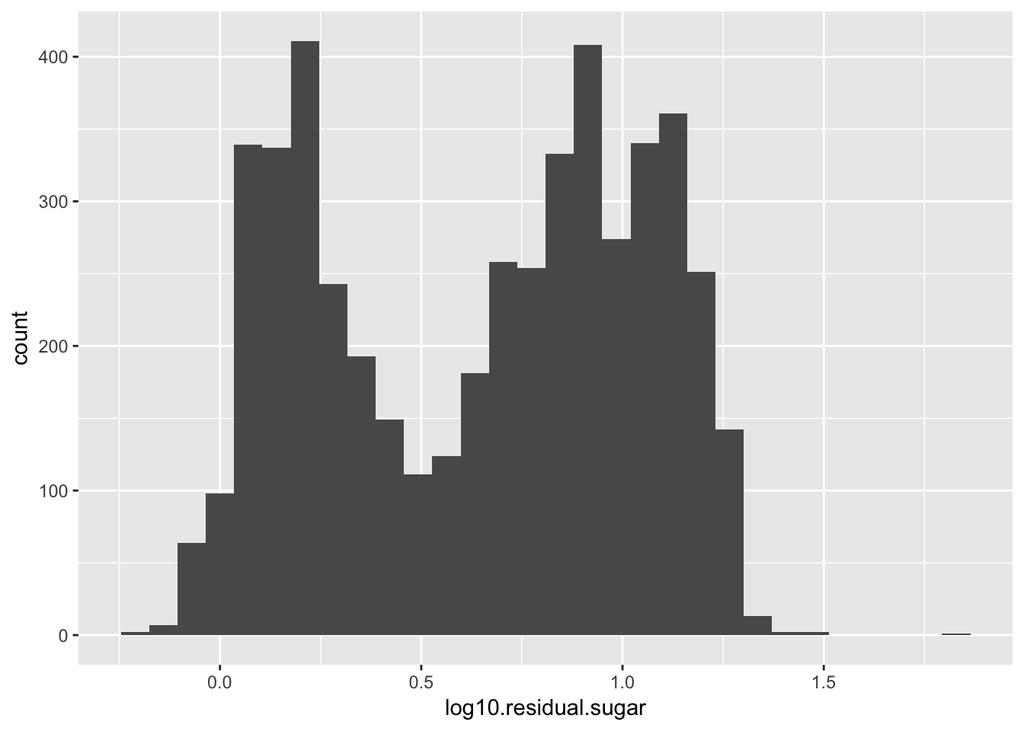

```r
WhiteWines$log10.residual.sugar <- log10( WhiteWines$residual.sugar)
qplot(x = log10.residual.sugar, data = WhiteWines)
```

```r
summary(WhiteWines$log10.residual.sugar)
```

```
##    Min. 1st Qu.  Median    Mean 3rd Qu.    Max.
## -0.2218  0.2304  0.7160  0.6432  0.9956  1.8180
```

I transformed the long tail data to better understang the distribution of residual sugar. The residual sugar appears bimodal with the peaks in 0.25 and 0.8.

### Total Sulfur Dioxide

Amount of free and bound forms of S02; in low concentrations, SO2 is mostly undetectable in wine, but at free SO2 concentrations over 50 ppm, SO2 becomes evident in the nose and taste of wine

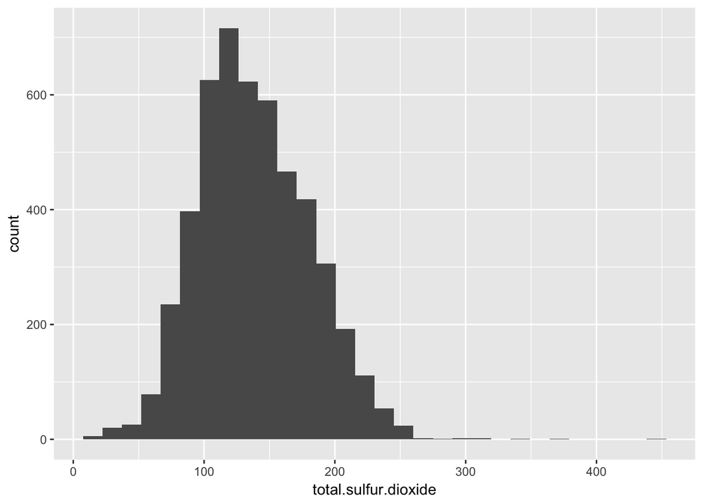

```r
qplot(x = total.sulfur.dioxide, data = WhiteWines)
```

```r
summary(WhiteWines$total.sulfur.dioxide)
```

```
##    Min. 1st Qu.  Median    Mean 3rd Qu.    Max.
##     9.0   108.0   134.0   138.4   167.0   440.0
```

It is a normal with it peak near 130 ppm, most of the data concentrated between 0-250 ppm and the minimum at 9 ppm and max at 440ppm.

```r
length(WhiteWines[(WhiteWines$total.sulfur.dioxide > 50),]$total.sulfur.dioxide)/length(WhiteWines$total.sulfur.dioxide)
```

```
## [1] 0.9899959
```

We also got that around 98.9% of the dataset have a more the SO2 more present in the wine.

### Free Sulfur Dioxide

The free form of SO2 exists in equilibrium between molecular SO2 (as a dissolved gas) and bisulfite ion; it prevents microbial growth and the oxidation of wine.

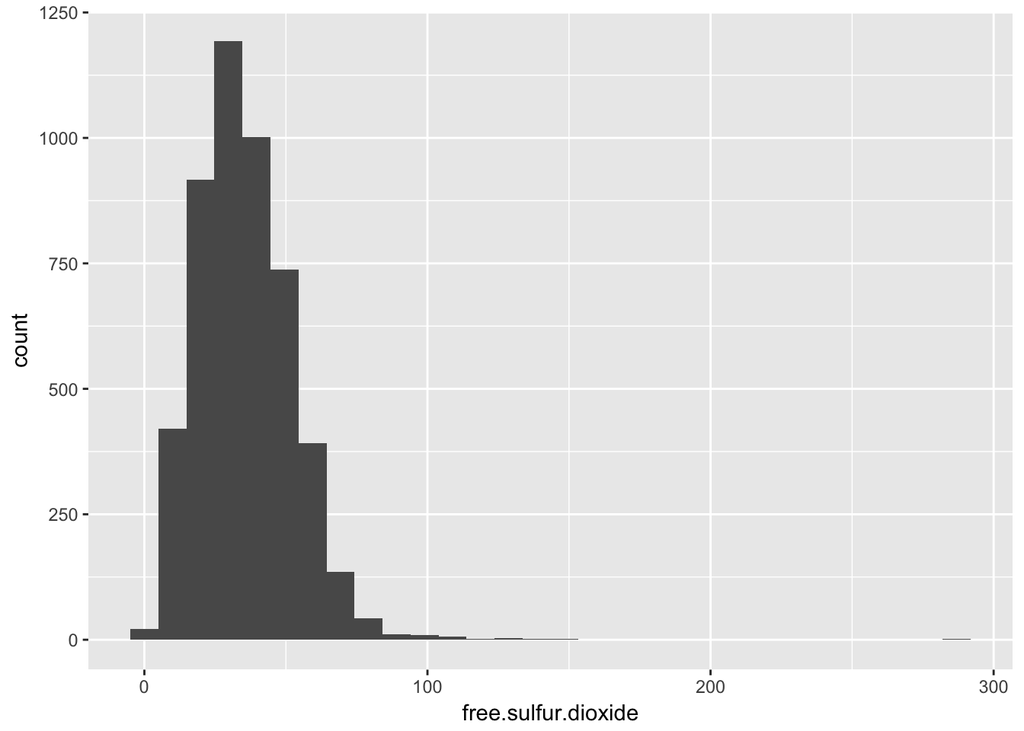

```r
qplot(x = free.sulfur.dioxide, data = WhiteWines)
```

```r
summary(WhiteWines$free.sulfur.dioxide)
```

```
##    Min. 1st Qu.  Median    Mean 3rd Qu.    Max.
##    2.00   23.00   34.00   35.31   46.00  289.00
```

Lets see the others values as well. I suppose that ph and density may be also correlated.

### PH

Describes how acidic or basic a wine is on a scale from 0 (very acidic) to 14 (very basic); most wines are between 3-4 on the pH scale

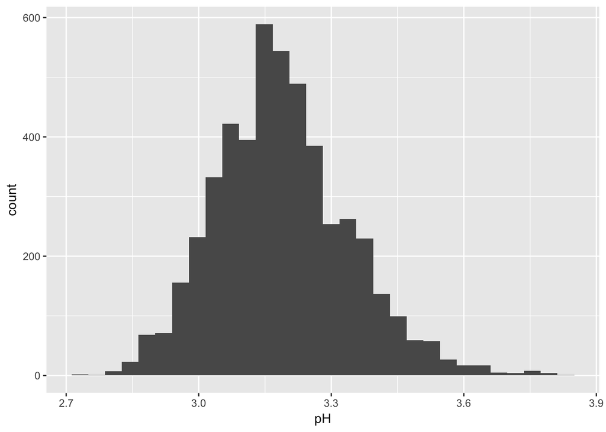

```r
qplot(x=pH, data=WhiteWines)
```

```r
summary(WhiteWines$pH)
```

```
##    Min. 1st Qu.  Median    Mean 3rd Qu.    Max.
##   2.720   3.090   3.180   3.188   3.280   3.820
```

We get that all wines are acid (pH < 7) and it has a normal distribution most of it at 3.1 and min 2.720 and max 3.820.

### Density

The density of water is close to that of water depending on the percent alcohol and sugar content.

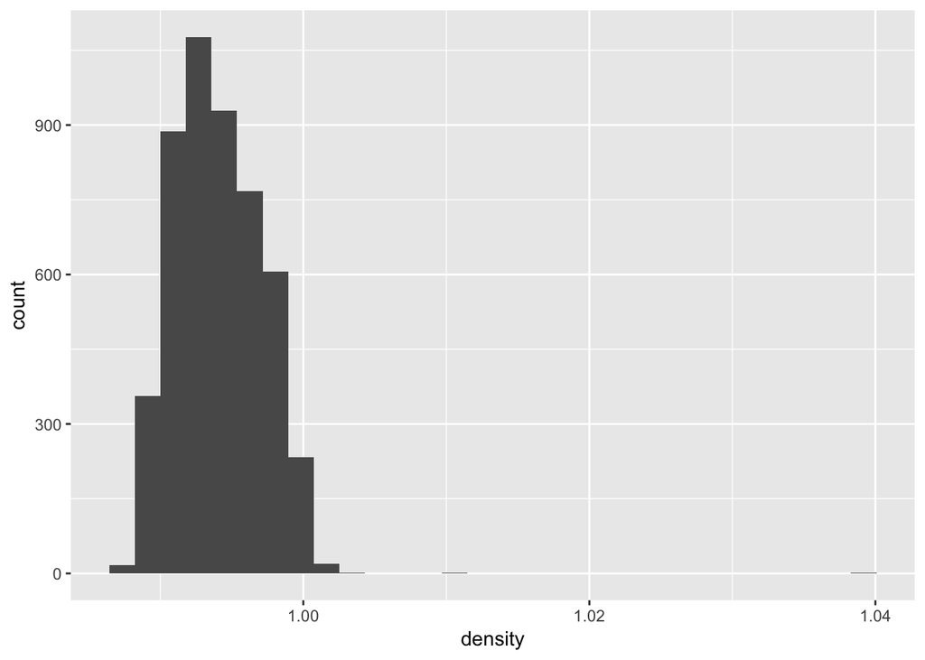

```r
qplot(x=density,data=WhiteWines)
```

```r
summary(WhiteWines$density)
```

```
##    Min. 1st Qu.  Median    Mean 3rd Qu.    Max.
##  0.9871  0.9917  0.9937  0.9940  0.9961  1.0390
```

It is a normal peak at of it at 0.9937 and min at 0.987 and max near 1.04. It is concentrated at 0.9 to 1.00. That means that density of most wines are very near to the water density, that is 1.

### Chlorides

Is the amount of salt in the wine. I wonder how this can affect quality.

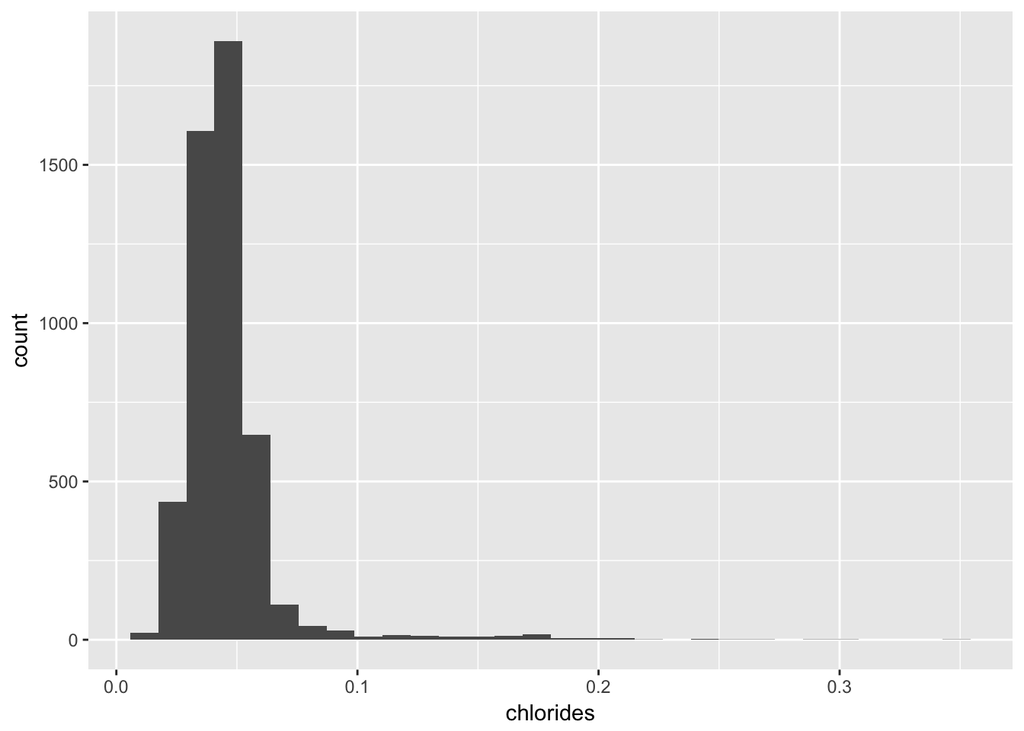

```r
qplot(x=chlorides,data=WhiteWines)
```

```r
summary(WhiteWines$chlorides)
```

```
##    Min. 1st Qu.  Median    Mean 3rd Qu.    Max.
## 0.00900 0.03600 0.04300 0.04577 0.05000 0.34600
```

Is also a normal with peak at 0.043 and it is concentrated between 0.009 and 0,09 and the min is at 0.009 and max at 0.34. I suppose be the less than 0.04 have best quality,

### Sulphates

A wine additive which can contribute to sulfur dioxide gas (S02) levels, wich acts as an antimicrobial and antioxidant

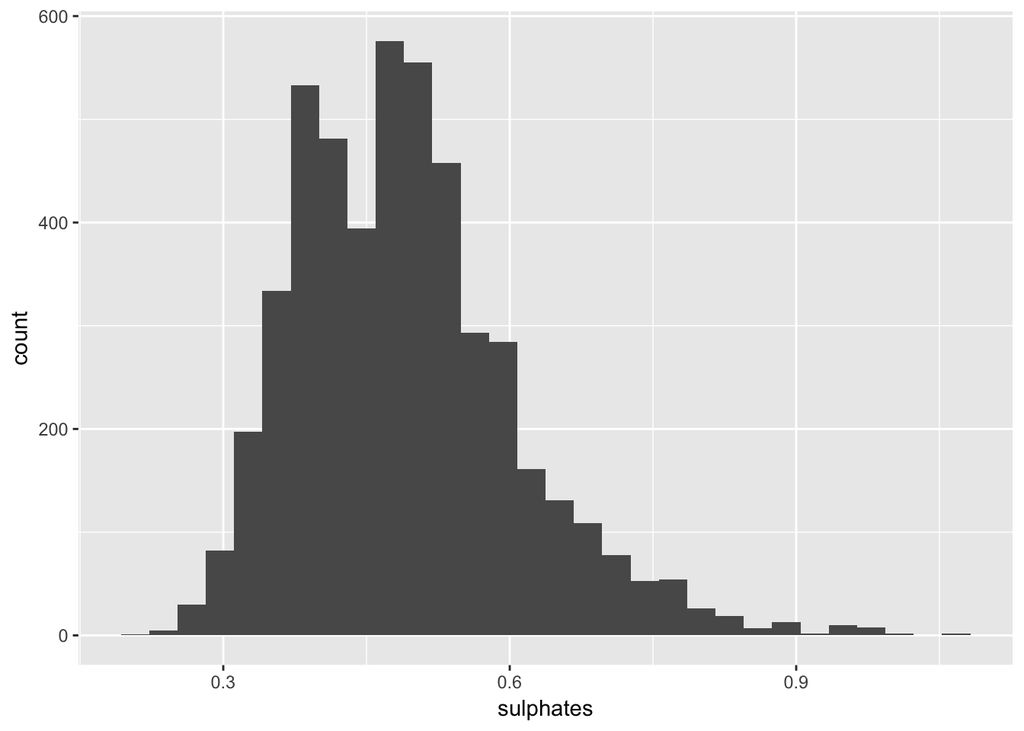

```r
qplot(x=sulphates,data=WhiteWines)
```

```r
summary(WhiteWines$sulphates)
```

```
##    Min. 1st Qu.  Median    Mean 3rd Qu.    Max.
##  0.2200  0.4100  0.4700  0.4898  0.5500  1.0800
```

We got a binormal with peaks near 0.4 and 0.5. Min value is 0.2 and max 1.08.

### Acids

Lwts see the acid. There are three types of acids: 1 - fixed acidity: most acids involved with wine or fixed or nonvolatile (do not evaporate readily) 2 - volatile acidity: the amount of acetic acid in wine, which at too high of levels can lead to an unpleasant, vinegar taste 3 - citric acid: found in small quantities, citric acid can add ‘freshness’ and flavor to wines

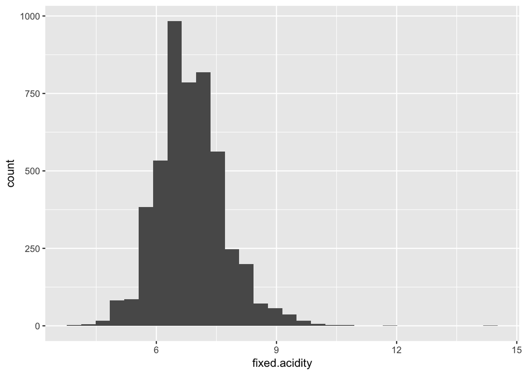

```r
qplot(x=fixed.acidity,data=WhiteWines)
```

```r
summary(WhiteWines$fixed.acidity)
```

```
##    Min. 1st Qu.  Median    Mean 3rd Qu.    Max.
##   3.800   6.300   6.800   6.855   7.300  14.200
```

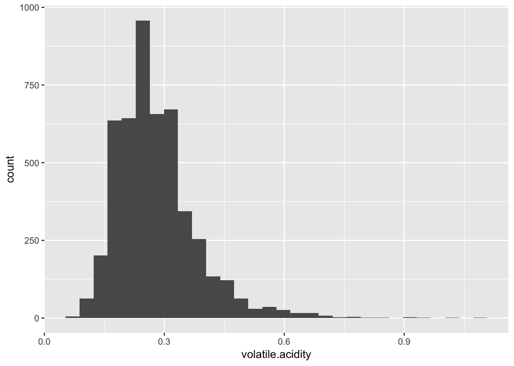

```r
qplot(x=volatile.acidity,data=WhiteWines)
```

```r
summary(WhiteWines$volatile.acidity)
```

```
##    Min. 1st Qu.  Median    Mean 3rd Qu.    Max.
##  0.0800  0.2100  0.2600  0.2782  0.3200  1.1000
```

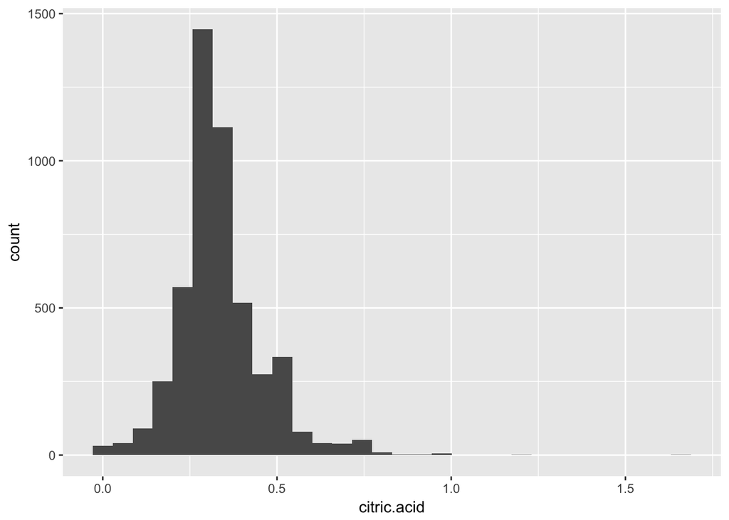

```r
qplot(x=citric.acid,data=WhiteWines)
```

```r
summary(WhiteWines$citric.acid)
```

```
##    Min. 1st Qu.  Median    Mean 3rd Qu.    Max.
##  0.0000  0.2700  0.3200  0.3342  0.3900  1.6600
```

Comparasion:

In all of them we got a normal. We have more fixed acid than the others and it peak is in 7 when the other is in 0.3 and with a higher variance.

Lets aggregate the acids and see what it returns.

```r
WhiteWines$acid <- WhiteWines$citric.acid + WhiteWines$fixed.acidity + WhiteWines$volatile.acidity
```

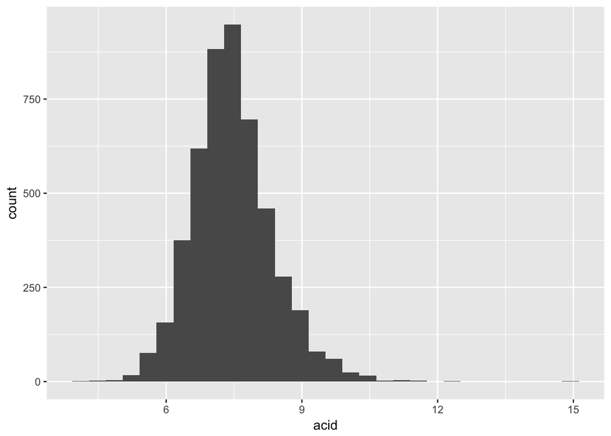

```r
qplot(x=acid,data=WhiteWines)
```

```r
summary(WhiteWines$acid)
```

```
##    Min. 1st Qu.  Median    Mean 3rd Qu.    Max.
##   4.130   6.890   7.405   7.467   7.960  14.960
```

When analyzing the new feature we got that it is more similar to fixed aciity with it peak at 7.5.

### What is/are the main feature(s) of interest in your dataset?

The main features in the dataset are quality,alcohol and density I’d like to determine which features are better to predict the quality of a wine. I suspect that a combination of density, alcohol and others features can contribute for it.

### What other features in the dataset do you think will help support your investigation into your feature(s) of interest?

Residual sugar,clorides,ph,sulphates and others my contribute to the quality of a wine.

### Did you create any new variables from existing variables in the dataset?

I created three differente features one for factorizing the quality of the wine, other by transfoming the residual sugar feature to log10 and other by combining the three different acids (fixed, volative and citric). I did so in other to better visualize the relations between the differents features.

### Of the features you investigated, were there any unusual distributions? Did you perform any operations on the data to tidy, adjust, or change the form of the data? If so, why did you do this?

# Bivariate Plots Section

> **Tip**: Based on what you saw in the univariate plots, what relationships between variables might be interesting to look at in this section? Don’t limit yourself to relationships between a main output feature and one of the supporting variables. Try to look at relationships between supporting variables as well.

We will now see the correlation matrix. To see wich variables are correlated to quality and each other.

```r
correlation_matrix <- cor(WhiteWines[,c(1:13,15,16)])
round(correlation_matrix,2)
```

```
##                          X fixed.acidity volatile.acidity citric.acid
## X                     1.00         -0.26             0.00       -0.15
## fixed.acidity        -0.26          1.00            -0.02        0.29
## volatile.acidity      0.00         -0.02             1.00       -0.15
## citric.acid          -0.15          0.29            -0.15        1.00
## residual.sugar        0.01          0.09             0.06        0.09
## chlorides            -0.05          0.02             0.07        0.11
## free.sulfur.dioxide  -0.01         -0.05            -0.10        0.09
## total.sulfur.dioxide -0.16          0.09             0.09        0.12
## density              -0.19          0.27             0.03        0.15
## pH                   -0.12         -0.43            -0.03       -0.16
## sulphates             0.01         -0.02            -0.04        0.06
## alcohol               0.21         -0.12             0.07       -0.08
## quality               0.04         -0.11            -0.19       -0.01
## log10.residual.sugar  0.02          0.07             0.09        0.06
## acid                 -0.26          0.99             0.07        0.39
##                      residual.sugar chlorides free.sulfur.dioxide
## X                              0.01     -0.05               -0.01
## fixed.acidity                  0.09      0.02               -0.05
## volatile.acidity               0.06      0.07               -0.10
## citric.acid                    0.09      0.11                0.09
## residual.sugar                 1.00      0.09                0.30
## chlorides                      0.09      1.00                0.10
## free.sulfur.dioxide            0.30      0.10                1.00
## total.sulfur.dioxide           0.40      0.20                0.62
## density                        0.84      0.26                0.29
## pH                            -0.19     -0.09                0.00
## sulphates                     -0.03      0.02                0.06
## alcohol                       -0.45     -0.36               -0.25
## quality                       -0.10     -0.21                0.01
## log10.residual.sugar           0.93      0.07                0.31
## acid                           0.10      0.05               -0.05
##                      total.sulfur.dioxide density    pH sulphates alcohol
## X                                   -0.16   -0.19 -0.12      0.01    0.21
## fixed.acidity                        0.09    0.27 -0.43     -0.02   -0.12
## volatile.acidity                     0.09    0.03 -0.03     -0.04    0.07
## citric.acid                          0.12    0.15 -0.16      0.06   -0.08
## residual.sugar                       0.40    0.84 -0.19     -0.03   -0.45
## chlorides                            0.20    0.26 -0.09      0.02   -0.36
## free.sulfur.dioxide                  0.62    0.29  0.00      0.06   -0.25
```

[output cut: 9 more lines]

```
## X                       0.04                 0.02 -0.26
## fixed.acidity          -0.11                 0.07  0.99
## volatile.acidity       -0.19                 0.09  0.07
## citric.acid            -0.01                 0.06  0.39
## residual.sugar         -0.10                 0.93  0.10
## chlorides              -0.21                 0.07  0.05
## free.sulfur.dioxide     0.01                 0.31 -0.05
## total.sulfur.dioxide   -0.17                 0.42  0.11
## density                -0.31                 0.76  0.28
## pH                      0.10                -0.18 -0.43
## sulphates               0.05                -0.03 -0.01
## alcohol                 0.44                -0.39 -0.12
## quality                 1.00                -0.06 -0.13
## log10.residual.sugar   -0.06                 1.00  0.09
## acid                   -0.13                 0.09  1.00
```

Looking more carefully with the row quality we got that quality is positivly and more correlated to alcohol. Other feature that is correlated but negatively is with density and clorides.

```r
sort(correlation_matrix[13,])
```

```
##              density            chlorides     volatile.acidity
##         -0.307123313         -0.209934411         -0.194722969
## total.sulfur.dioxide                 acid        fixed.acidity
##         -0.174737218         -0.131377207         -0.113662831
##       residual.sugar log10.residual.sugar          citric.acid
##         -0.097576829         -0.064631762         -0.009209091
##  free.sulfur.dioxide                    X            sulphates
##          0.008158067          0.035763247          0.053677877
##                   pH              alcohol              quality
##          0.099427246          0.435574715          1.000000000
```

Lets see a visualization of this matrix.

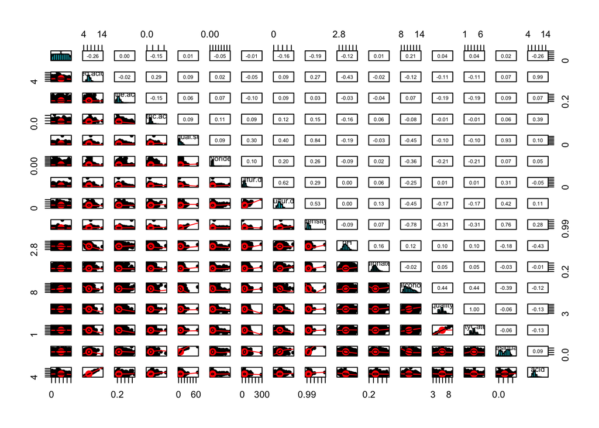

# Bivariate Analysis

Lets take a closer look at the relation between alcohol and density with quality.

```r
WhiteWines$Qualitycat<-as.factor(WhiteWines$quality)
```

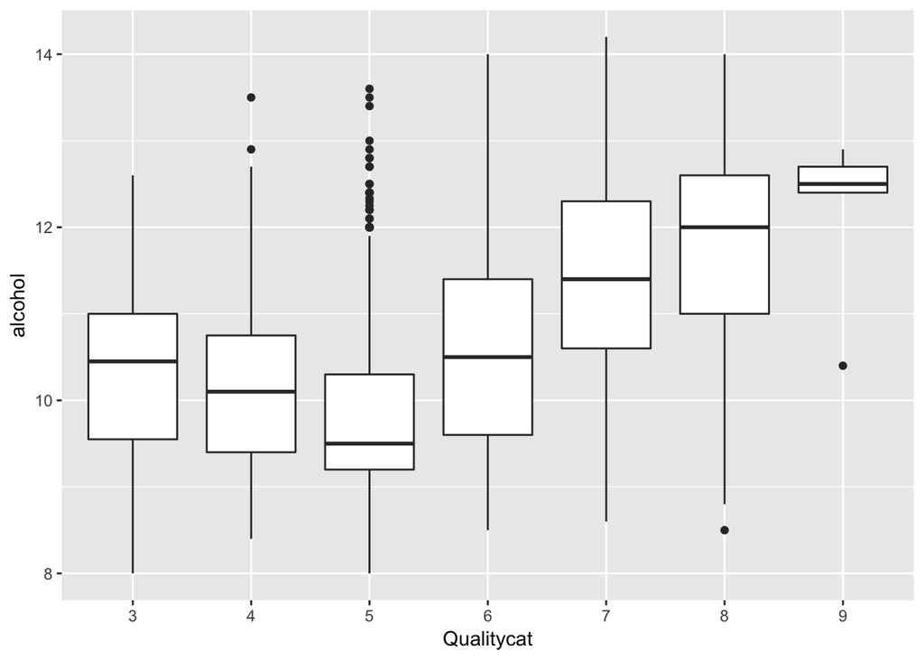

```r
ggplot(aes(y = alcohol,x = Qualitycat),data = WhiteWines) + geom_boxplot() + geom_smooth(method = 'lm')
```

```r
tapply(WhiteWines$alcohol,WhiteWines$Qualitycat, summary)
```

```
## $`3`
##    Min. 1st Qu.  Median    Mean 3rd Qu.    Max.
##    8.00    9.55   10.45   10.34   11.00   12.60
##
## $`4`
##    Min. 1st Qu.  Median    Mean 3rd Qu.    Max.
##    8.40    9.40   10.10   10.15   10.75   13.50
##
## $`5`
##    Min. 1st Qu.  Median    Mean 3rd Qu.    Max.
##   8.000   9.200   9.500   9.809  10.300  13.600
##
## $`6`
##    Min. 1st Qu.  Median    Mean 3rd Qu.    Max.
##    8.50    9.60   10.50   10.58   11.40   14.00
##
## $`7`
##    Min. 1st Qu.  Median    Mean 3rd Qu.    Max.
##    8.60   10.60   11.40   11.37   12.30   14.20
##
## $`8`
##    Min. 1st Qu.  Median    Mean 3rd Qu.    Max.
##    8.50   11.00   12.00   11.64   12.60   14.00
##
## $`9`
##    Min. 1st Qu.  Median    Mean 3rd Qu.    Max.
##   10.40   12.40   12.50   12.18   12.70   12.90
```

We see that as alcohol in the wines increases the quality tend to increase as well and that with alcohol percentage more than 10.8 tend to have better quality. Now lets take a look at density.

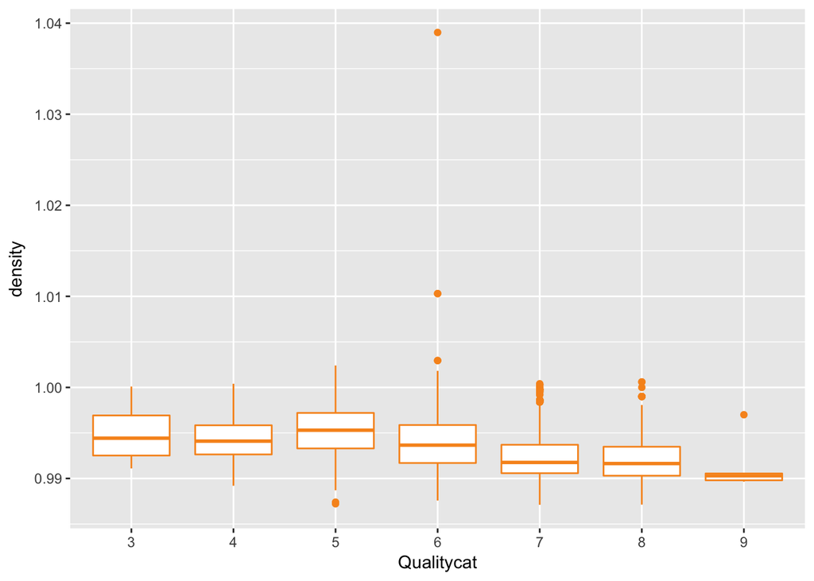

```r
ggplot(aes(x = Qualitycat, y = density),data = WhiteWines) + geom_boxplot(color = '#F79420')
```

```r
tapply(WhiteWines$density,WhiteWines$Qualitycat, summary)
```

```
## $`3`
##    Min. 1st Qu.  Median    Mean 3rd Qu.    Max.
##  0.9911  0.9925  0.9944  0.9949  0.9969  1.0000
##
## $`4`
##    Min. 1st Qu.  Median    Mean 3rd Qu.    Max.
##  0.9892  0.9926  0.9941  0.9943  0.9958  1.0000
##
## $`5`
##    Min. 1st Qu.  Median    Mean 3rd Qu.    Max.
##  0.9872  0.9933  0.9953  0.9953  0.9972  1.0020
##
## $`6`
##    Min. 1st Qu.  Median    Mean 3rd Qu.    Max.
##  0.9876  0.9917  0.9937  0.9940  0.9959  1.0390
##
## $`7`
##    Min. 1st Qu.  Median    Mean 3rd Qu.    Max.
##  0.9871  0.9906  0.9918  0.9925  0.9937  1.0000
##
## $`8`
##    Min. 1st Qu.  Median    Mean 3rd Qu.    Max.
##  0.9871  0.9903  0.9916  0.9922  0.9935  1.0010
##
## $`9`
##    Min. 1st Qu.  Median    Mean 3rd Qu.    Max.
##  0.9896  0.9898  0.9903  0.9915  0.9906  0.9970
```

It seems that low density tend to a better quality. As it goes to near 0.99 it’s Quality tend to increases.

Now let us compare to chorlides.

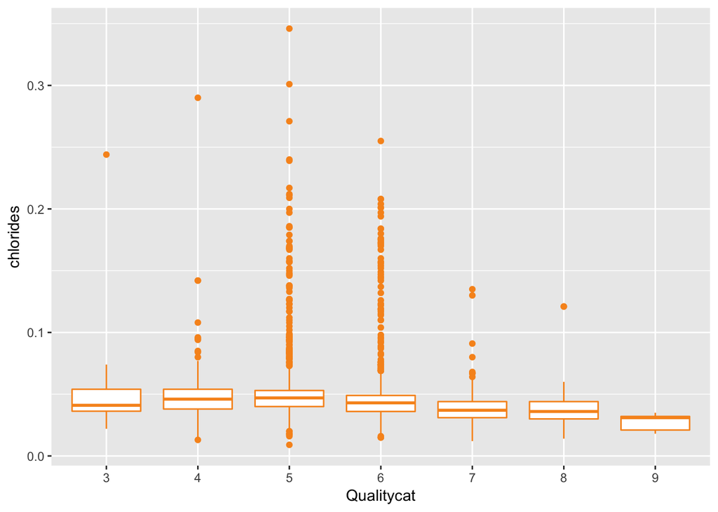

```r
ggplot(aes(x = Qualitycat, y = chlorides),data = WhiteWines) + geom_boxplot(color = '#F79420')
```

### Talk about some of the relationships you observed in this part of the investigation. How did the feature(s) of interest vary with other features in the dataset?

### Did you observe any interesting relationships between the other features (not the main feature(s) of interest)?

### What was the strongest relationship you found?

# Multivariate Plots Section

> **Tip**: Now it’s time to put everything together. Based on what you found in the bivariate plots section, create a few multivariate plots to investigate more complex interactions between variables. Make sure that the plots that you create here are justified by the plots you explored in the previous section. If you plan on creating any mathematical models, this is the section where you will do that.

# Multivariate Analysis

### Talk about some of the relationships you observed in this part of the investigation. Were there features that strengthened each other in terms of looking at your feature(s) of interest?

### Were there any interesting or surprising interactions between features?

### OPTIONAL: Did you create any models with your dataset? Discuss the strengths and limitations of your model.

# Final Plots and Summary

> **Tip**: You’ve done a lot of exploration and have built up an understanding of the structure of and relationships between the variables in your dataset. Here, you will select three plots from all of your previous exploration to present here as a summary of some of your most interesting findings. Make sure that you have refined your selected plots for good titling, axis labels (with units), and good aesthetic choices (e.g. color, transparency). After each plot, make sure you justify why you chose each plot by describing what it shows.

### Plot One

### Description One

### Plot Two

### Description Two

### Plot Three

### Description Three

# Reflection

> **Tip**: Here’s the final step! Reflect on the exploration you performed and the insights you found. What were some of the struggles that you went through? What went well? What was surprising? Make sure you include an insight into future work that could be done with the dataset.

> **Tip**: Don’t forget to remove this, and the other **Tip** sections before saving your final work and knitting the final report!